# Bird Strike

```python
import numpy as np
import pandas as pd
import matplotlib.pyplot as plt
import seaborn as sns
pd.set_option('display.max_columns', 50)
```

[figure not shown]

```python
from IPython.display import Image, display

display(Image(filename=r'C:\Users\user\Downloads\bird-strike-story.jpg'))
```

A bird strike is strictly defined as a collision between a bird and an aircraft which is in flight or on a take-off or landing roll. The term is often expanded to cover other wildlife strikes - with bats or ground animals. Bird Strike is common and can be a significant threat to aircraft safety.Transport and communication are in the crucial domain in the field of analytics.Environmental impacts and safety are, nowadays, two major concerns of the scientific community with respect to transport scenarios and to the ever-growing urban areas. These issues gain more importance due to the increasing amount of vehicles and people. Seeking new solutions is reaching a point where available technologies andartificial intelligence, especially MAS, are being recognized as ways to cope with and tackle these kinds of problems in a distributed and more appropriate way. For smaller aircraft, significant damage may be caused to the aircraft structure and all aircraft, especially jet-engine ones, are vulnerable to the loss of thrust which can follow the ingestion of birds into engine air intakes. This has resulted in several fatal accidents.

Bird strikes may occur during any phase of flight, but are most likely during the take-off, initial climb, approach and landing phases due to the greater numbers of birds in flight at lower levels. To have a closer look the following document visually depicts the data collected on Bird Strikes by FAA between 2000-2011

```python
df=pd.read_csv("Bird Strikes data.xlsx - Bird Strikes.csv")
```

```python
df.head()
```

|  | Record ID | Aircraft: Type | Airport: Name | Altitude bin | Aircraft: Make/Model | Wildlife: Number struck | Wildlife: Number Struck Actual | Effect: Impact to flight | FlightDate | Effect: Indicated Damage | Aircraft: Number of engines? | Aircraft: Airline/Operator | Origin State | When: Phase of flight | Conditions: Precipitation | Remains of wildlife collected? | Remains of wildlife sent to Smithsonian | Remarks | Wildlife: Size | Conditions: Sky | Wildlife: Species | Pilot warned of birds or wildlife? | Cost: Total $ | Feet above ground | Number of people injured | Is Aircraft Large? |
| --- | --- | --- | --- | --- | --- | --- | --- | --- | --- | --- | --- | --- | --- | --- | --- | --- | --- | --- | --- | --- | --- | --- | --- | --- | --- | --- |
| 0 | 202152 | Airplane | LAGUARDIA NY | > 1000 ft | B-737-400 | Over 100 | 859 | Engine Shut Down | 11/23/00 0:00 | Caused damage | 2 | US AIRWAYS* | New York | Climb | NaN | False | False | FLT 753. PILOT REPTD A HUNDRED BIRDS ON UNKN T... | Medium | No Cloud | Unknown bird - medium | N | 30,736 | 1,500 | 0 | Yes |
| 1 | 208159 | Airplane | DALLAS/FORT WORTH INTL ARPT | < 1000 ft | MD-80 | Over 100 | 424 | NaN | 7/25/01 0:00 | Caused damage | 2 | AMERICAN AIRLINES | Texas | Landing Roll | NaN | False | False | 102 CARCASSES FOUND. 1 LDG LIGHT ON NOSE GEAR ... | Small | Some Cloud | Rock pigeon | Y | 0 | 0 | 0 | No |
| 2 | 207601 | Airplane | LAKEFRONT AIRPORT | < 1000 ft | C-500 | Over 100 | 261 | NaN | 9/14/01 0:00 | No damage | 2 | BUSINESS | Louisiana | Approach | NaN | False | False | FLEW UNDER A VERY LARGE FLOCK OF BIRDS OVER AP... | Small | No Cloud | European starling | N | 0 | 50 | 0 | No |
| 3 | 215953 | Airplane | SEATTLE-TACOMA INTL | < 1000 ft | B-737-400 | Over 100 | 806 | Precautionary Landing | 9/5/02 0:00 | No damage | 2 | ALASKA AIRLINES | Washington | Climb | NaN | True | False | NOTAM WARNING. 26 BIRDS HIT THE A/C, FORCING A... | Small | Some Cloud | European starling | Y | 0 | 50 | 0 | Yes |
| 4 | 219878 | Airplane | NORFOLK INTL | < 1000 ft | CL-RJ100/200 | Over 100 | 942 | NaN | 6/23/03 0:00 | No damage | 2 | COMAIR AIRLINES | Virginia | Approach | NaN | False | False | NO DMG REPTD. | Small | No Cloud | European starling | N | 0 | 50 | 0 | No |

```python
df.shape
```

```
(25558, 26)
```

```python
df.columns
```

```
Index(['Record ID', 'Aircraft: Type', 'Airport: Name', 'Altitude bin',
       'Aircraft: Make/Model', 'Wildlife: Number struck',
       'Wildlife: Number Struck Actual', 'Effect: Impact to flight',
       'FlightDate', 'Effect: Indicated Damage',
       'Aircraft: Number of engines?', 'Aircraft: Airline/Operator',
       'Origin State', 'When: Phase of flight', 'Conditions: Precipitation',
       'Remains of wildlife collected?',
       'Remains of wildlife sent to Smithsonian', 'Remarks', 'Wildlife: Size',
       'Conditions: Sky', 'Wildlife: Species',
       'Pilot warned of birds or wildlife?', 'Cost: Total $',
       'Feet above ground', 'Number of people injured', 'Is Aircraft Large?'],
      dtype='object')
```

```python
df.info()
```

```
<class 'pandas.core.frame.DataFrame'>
RangeIndex: 25558 entries, 0 to 25557
Data columns (total 26 columns):
 #   Column                                   Non-Null Count  Dtype
---  ------                                   --------------  -----
 0   Record ID                                25558 non-null  int64
 1   Aircraft: Type                           25429 non-null  object
 2   Airport: Name                            25429 non-null  object
 3   Altitude bin                             25429 non-null  object
 4   Aircraft: Make/Model                     25558 non-null  object
 5   Wildlife: Number struck                  25429 non-null  object
 6   Wildlife: Number Struck Actual           25558 non-null  int64
 7   Effect: Impact to flight                 2078 non-null   object
 8   FlightDate                               25429 non-null  object
 9   Effect: Indicated Damage                 25558 non-null  object
```

[output cut: 18 more lines]

```python
df.dtypes
```

```
Record ID                                   int64
Aircraft: Type                             object
Airport: Name                              object
Altitude bin                               object
Aircraft: Make/Model                       object
Wildlife: Number struck                    object
Wildlife: Number Struck Actual              int64
Effect: Impact to flight                   object
FlightDate                                 object
Effect: Indicated Damage                   object
Aircraft: Number of engines?               object
Aircraft: Airline/Operator                 object
Origin State                               object
When: Phase of flight                      object
Conditions: Precipitation                  object
Remains of wildlife collected?               bool
Remains of wildlife sent to Smithsonian      bool
Remarks                                    object
Wildlife: Size                             object
Conditions: Sky                            object
Wildlife: Species                          object
Pilot warned of birds or wildlife?         object
Cost: Total $                              object
Feet above ground                          object
Number of people injured                    int64
Is Aircraft Large?                         object
dtype: object
```

```python
df['Year'] = pd.to_datetime(df['FlightDate']).dt.year
#df['Year']=df['FlightDate'].dt.year
df['Month']=pd.to_datetime(df['FlightDate']).dt.month
```

```python
df.describe()
```

|  | Record ID | Wildlife: Number Struck Actual | Number of people injured | Year | Month |
| --- | --- | --- | --- | --- | --- |
| count | 25558.000000 | 25558.000000 | 25558.000000 | 25429.000000 | 25429.000000 |
| mean | 253916.085609 | 2.691525 | 0.001056 | 2006.502772 | 7.210193 |
| std | 38510.453382 | 12.793975 | 0.050420 | 3.362241 | 2.793630 |
| min | 1195.000000 | 1.000000 | 0.000000 | 2000.000000 | 1.000000 |
| 25% | 225783.750000 | 1.000000 | 0.000000 | 2004.000000 | 5.000000 |
| 50% | 248749.000000 | 1.000000 | 0.000000 | 2007.000000 | 8.000000 |
| 75% | 269168.750000 | 1.000000 | 0.000000 | 2009.000000 | 9.000000 |
| max | 321909.000000 | 942.000000 | 6.000000 | 2011.000000 | 12.000000 |

# CASE STUDIES

● Visuals Depicting the Number of Bird Strikes

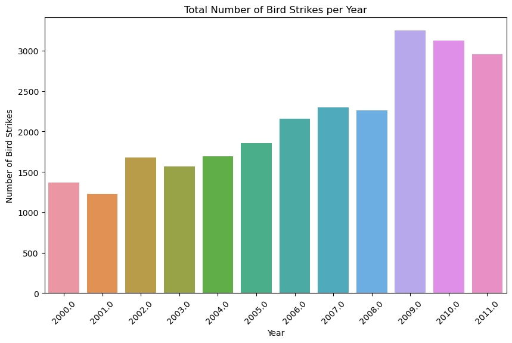

```python
plt.figure(figsize=(10, 6))
sns.countplot(data=df, x='Year')
plt.title('Total Number of Bird Strikes per Year')
plt.xlabel('Year')
plt.ylabel('Number of Bird Strikes')
plt.xticks(rotation=45)
plt.show()
```

📌In the above bar graph displays the total number of bird strikes reported each year. Look for trends over time, such as increases or decreases in the number of strikes.

● Yearly Analysis & Bird Strikes in the US

```python
yearly=df['Year'].value_counts().sort_index()
```

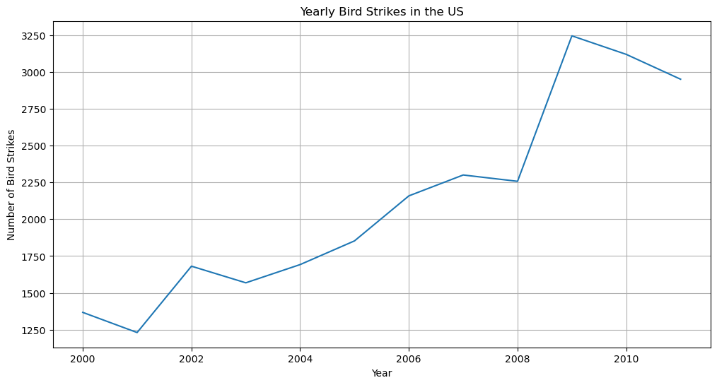

```python
plt.figure(figsize=(12, 6))
yearly.plot(kind='line')
plt.title('Yearly Bird Strikes in the US')
plt.xlabel('Year')
plt.ylabel('Number of Bird Strikes')
plt.grid(True)
plt.show()
```

📌This above line graph shows the number of bird strikes in the US over the years. In year 2001 the bird strikes in US start increases and decreases , but in year 2009 its at pinpoint with notable strikes

● Top 10 US Airlines in Terms of Having Encountered Bird Strikes

```python
top_airlines=df['Aircraft: Airline/Operator'].value_counts().head(10)
```

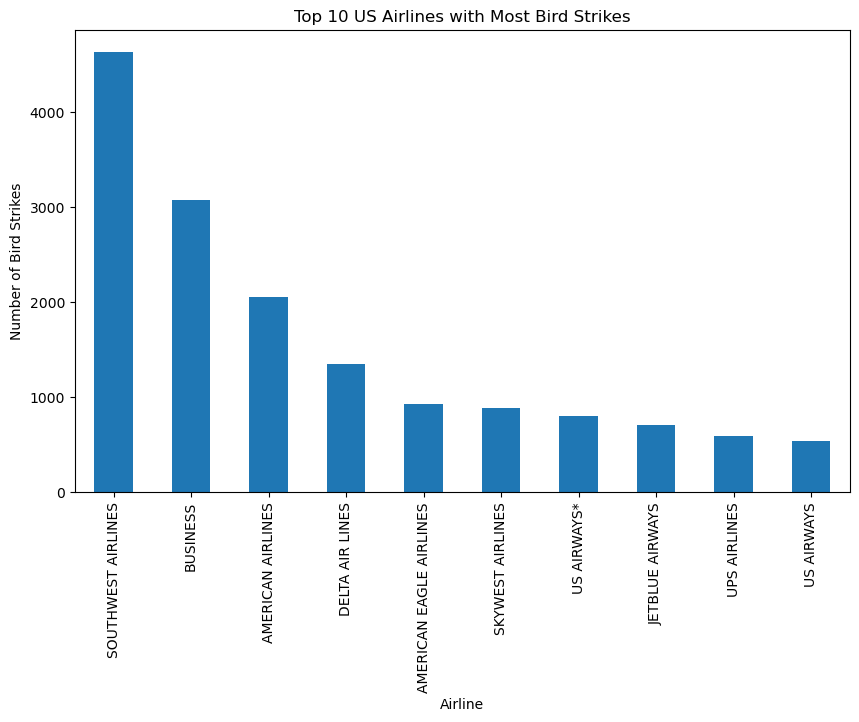

```python
plt.figure(figsize=(10,6))
top_airlines.plot(kind='bar')
plt.title('Top 10 US Airlines with Most Bird Strikes')
plt.xlabel('Airline')
plt.ylabel('Number of Bird Strikes')
plt.xticks(rotation=90)
plt.show()
```

📌The above bar graph shows that Southwest Airlines had most affected by bird strikes

● Airports with most incidents of bird strikes – Top 50

```python
top_airports=df['Airport: Name'].value_counts().head(50)
```

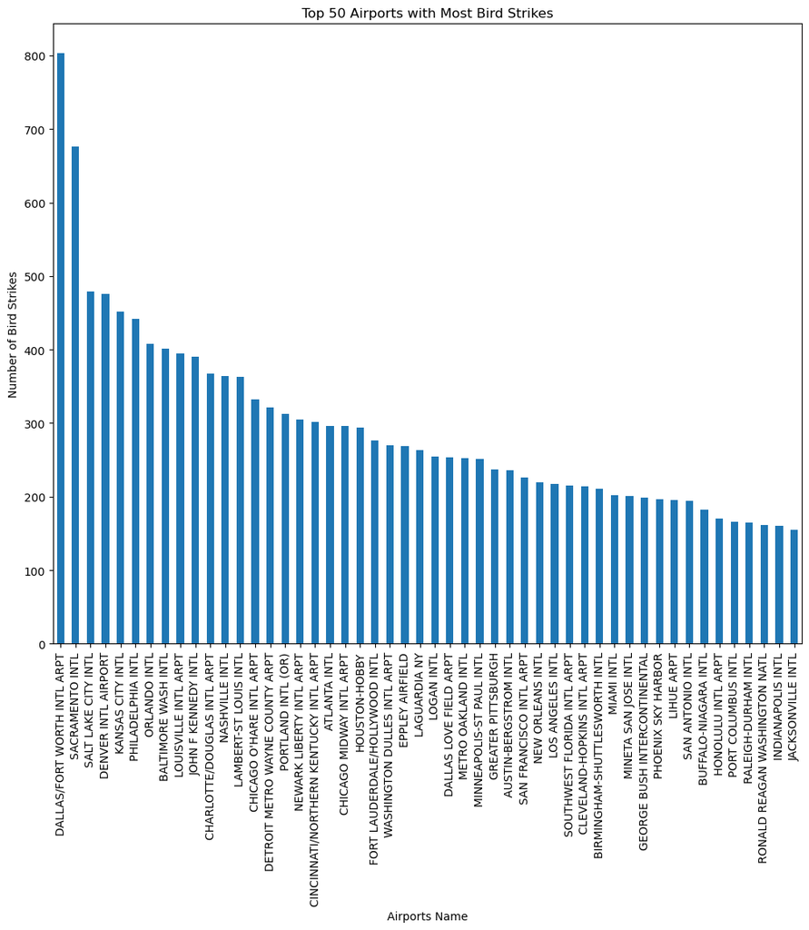

```python
plt.figure(figsize=(12, 10))
top_airports.plot(kind='bar')
plt.title('Top 50 Airports with Most Bird Strikes')
plt.xlabel('Airports Name')
plt.ylabel('Number of Bird Strikes')
plt.xticks(rotation=90)
plt.show()
```

📌This bar graph represents the top 50 Airports in which DALLAS/FORT WORTH INTL ARPT with taller bars have experienced more bird strikes.

● Yearly Cost Incurred due to Bird Strikes:

```python
df['Cost: Total $'] = df['Cost: Total $'].str.replace(',', '').astype(float, errors='ignore')
```

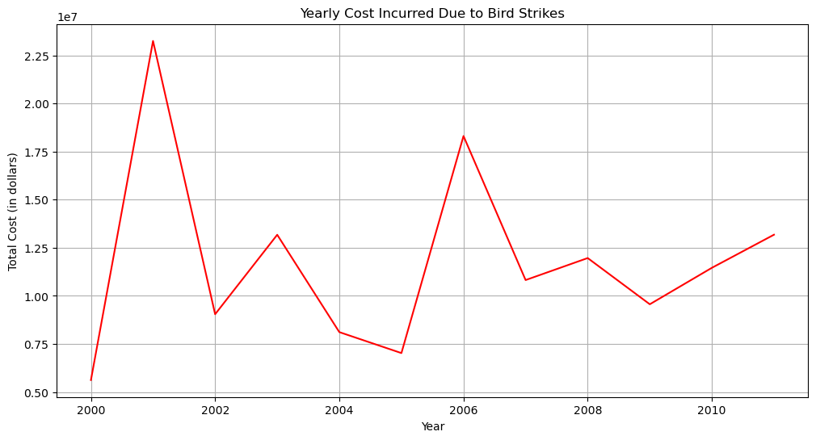

```
The total cost incurred due to bird stike is:Year
2000.0     5625496.0
2001.0    23252168.0
2002.0     9046405.0
2003.0    13176787.0
2004.0     8116866.0
2005.0     7026670.0
2006.0    18309903.0
2007.0    10822426.0
2008.0    11966121.0
2009.0     9564327.0
2010.0    11459879.0
2011.0    13180130.0
Name: Cost: Total $, dtype: float64
```

```python
Yearly_Cost = df.groupby('Year')['Cost: Total $'].sum()

plt.figure(figsize=(12, 6))
Yearly_Cost.plot(kind='line',color='red')
plt.title('Yearly Cost Incurred Due to Bird Strikes')
plt.xlabel('Year')
plt.ylabel('Total Cost (in dollars)')
plt.grid(True)
plt.show()
print(f'The total cost incurred due to bird stike is:{Yearly_Cost}')
```

📌The line shows how costs have changed over time. Look for years with high costs, indicating significant financial impacts due to bird strikes. In 2001 most highest financial impacts due to bird strikes

● When do most bird strikes occur?

```python
df['FlightDate']=pd.to_datetime(df['FlightDate'])
```

```python
df['hour'] = pd.to_datetime(df['FlightDate']).dt.hour
```

```python
def categorize_time(hour):
    if 0<= hour <6:
        return "Night"
    elif 6<= hour<12:
        return "Morning"
    elif 12<= hour<18:
        return "Afternoon"
    else:
        return "Evening"
```

```python
df["Time Category"]=df["hour"].apply(categorize_time)
```

```python
#time_category_counts=df['Time Category'].value_counts()
```

```python
time_category=df.groupby(['Year','Time Category']).size().unstack()
```

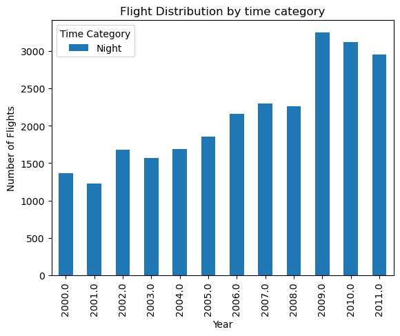

```python
time_category.plot(kind='bar',stacked=True)
plt.xlabel("Year")
plt.ylabel("Number of Flights")
plt.title("Flight Distribution by time category")
plt.show()
```

● Altitude of aeroplanes at the time of strike

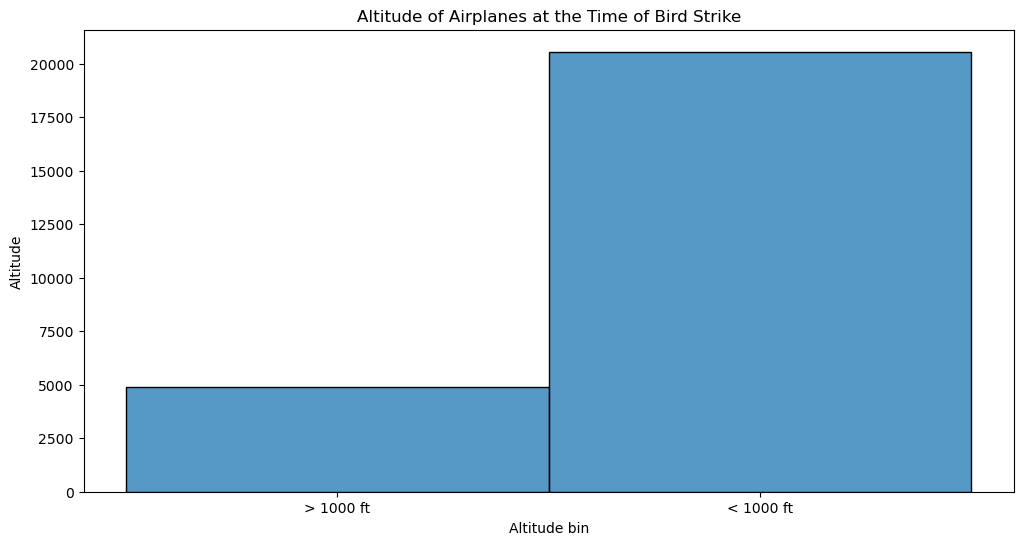

```python
plt.figure(figsize=(12, 6))
sns.histplot(data=df,x="Altitude bin",bins=50, kde=False,cbar=True)
plt.xlabel('Altitude bin')
plt.ylabel('Altitude')
plt.title('Altitude of Airplanes at the Time of Bird Strike')
plt.show()
```

```python
year_altitude=df.groupby(['Year','Altitude bin']).size().unstack()
```

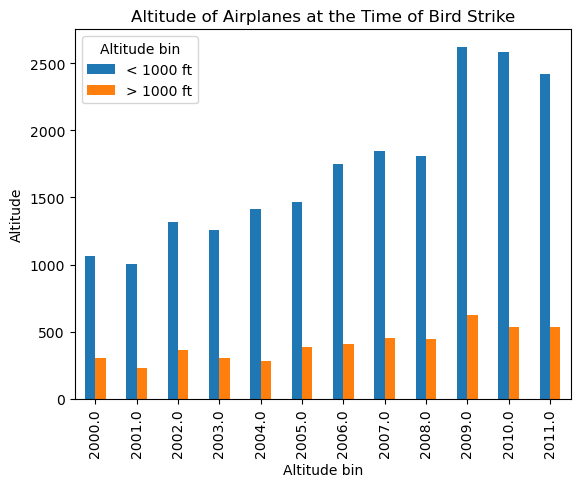

```python
plt.figure(figsize=(12, 6))
year_altitude.plot(kind='bar')
plt.xlabel('Altitude bin')
plt.ylabel('Altitude')
plt.title('Altitude of Airplanes at the Time of Bird Strike')
plt.show()
```

📌 20000 of bird strike incidents have happened when the altitude of airplane was <1000 ft and 5000 have happend when altitude was >1000 ft.

● Phase of flight at the time of the strike.

```python
phase_of_flight_Percentage=df['When: Phase of flight'].value_counts(normalize=True)*100
```

```python
colors=['skyblue','salmon','lightgreen','orange','lightcoral']
```

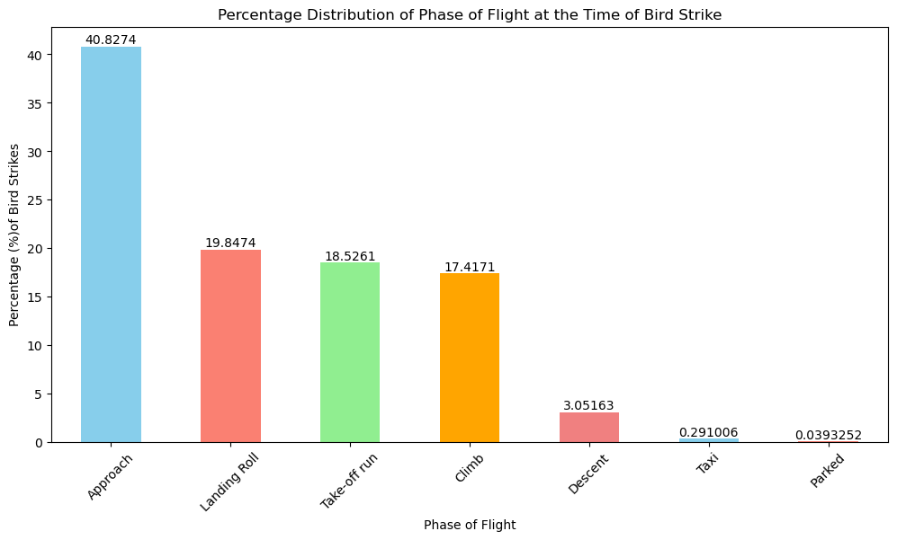

```python
plt.figure(figsize=(12,6))
ax=phase_of_flight_Percentage.plot(kind='bar',color=colors)
ax.bar_label(ax.containers[0])
plt.xlabel('Phase of Flight')
plt.ylabel('Percentage (%)of Bird Strikes')
plt.title('Percentage Distribution of Phase of Flight at the Time of Bird Strike')
plt.xticks(rotation=45)
plt.show()
```

📌At the time of Approach Phase approx 40.83% prone to bird strikes.

● Average Altitude of the aeroplanes in different phases at the time of strike

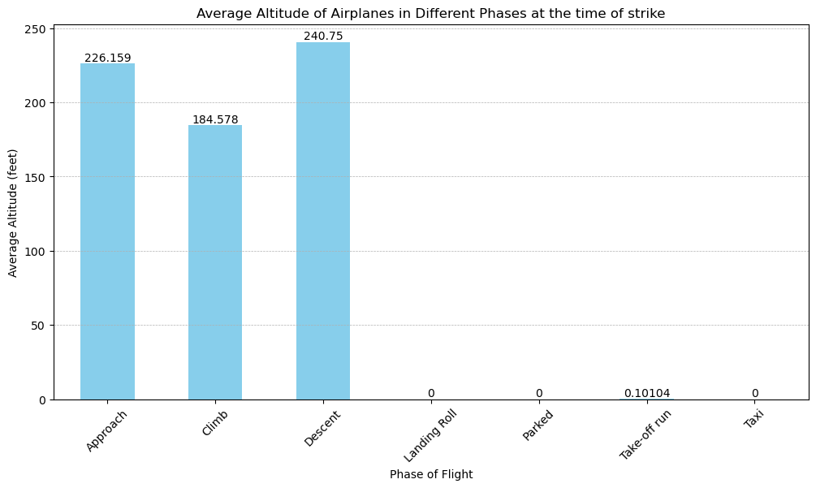

```
Average Altitude of Airplanes in Different Phases at the time of strike : When: Phase of flight
Approach        226.158614
Climb           184.578211
Descent         240.750000
Landing Roll      0.000000
Parked            0.000000
Take-off run      0.101040
Taxi              0.000000
Name: Feet above ground, dtype: float64
```

```python
df['Feet above ground']=pd.to_numeric(df['Feet above ground'],errors='coerce')
average_altitude = df.groupby('When: Phase of flight')['Feet above ground'].mean()
plt.figure(figsize=(12, 6))
ax=average_altitude.plot(kind='bar',color='skyblue')
ax.bar_label(ax.containers[0])
plt.title('Average Altitude of Airplanes in Different Phases at the time of strike')
plt.xlabel('Phase of Flight')
plt.ylabel('Average Altitude (feet)')
plt.xticks(rotation=45)
plt.grid(axis='y',linestyle='--',linewidth=0.5)
plt.show()
print("Average Altitude of Airplanes in Different Phases at the time of strike :",average_altitude )
```

● Effect of Bird Strikes & Impact on Flight

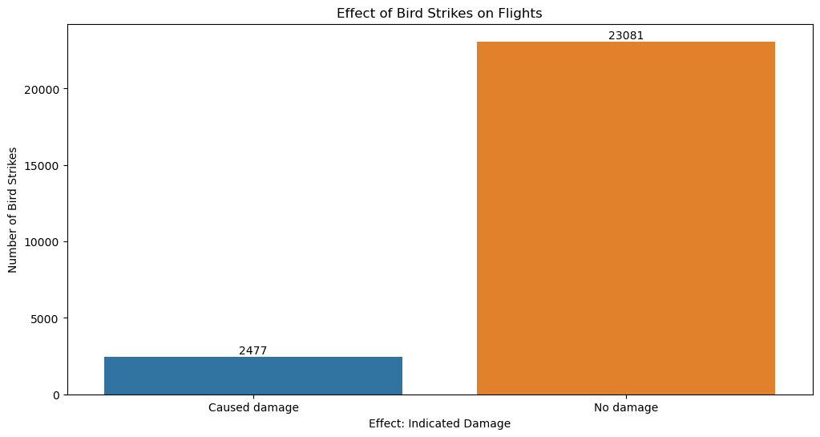

```python
plt.figure(figsize=(12, 6))
ax=sns.countplot(data=df, x='Effect: Indicated Damage')
ax.bar_label(ax.containers[0])
plt.xlabel('Effect: Indicated Damage')
plt.ylabel('Number of Bird Strikes')
plt.title('Effect of Bird Strikes on Flights')
plt.show()
```

📌23081 incidents caused no damage while 2477 incidents caused damage

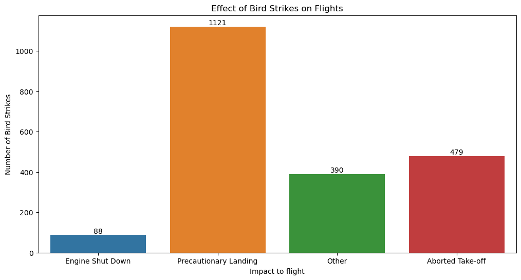

```python
plt.figure(figsize=(12, 6))
ax=sns.countplot(data=df, x='Effect: Impact to flight')
ax.bar_label(ax.containers[0])
plt.xlabel('Impact to flight')
plt.ylabel('Number of Bird Strikes')
plt.title('Effect of Bird Strikes on Flights')
plt.show()
```

📌 - 88 incidents where engine was shut down

📌 - 1121 incidents where there was precatioanry landing

```
📌   - 479 incidents where take off was abortt down
```

● Effect of Strike at Different Altitude

```python
altitude_effect_data=df[['Altitude bin','Effect: Impact to flight']]
```

```python
altitude_effect_data_counts=altitude_effect_data.groupby(['Altitude bin','Effect: Impact to flight']).size().unstack()
```

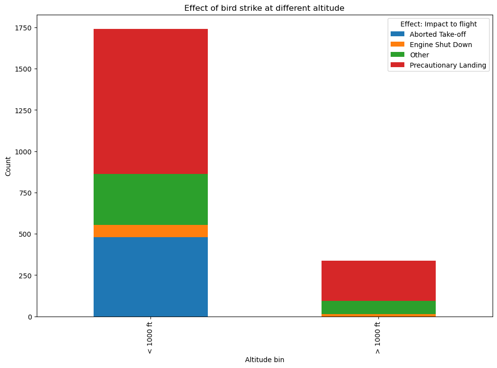

```python
altitude_effect_data_counts.plot(kind="bar",stacked=True,figsize=(12,8))
plt.xlabel("Altitude bin")
plt.ylabel("Count")
plt.title("Effect of bird strike at different altitude")
plt.legend(title='Effect: Impact to flight')
plt.show()
```

# 📌The above stacked bar chart is showing the distribution of the impact of bird strikes at different altitude.

● Were Pilots Informed? & Prior Warning and Effect of Strike Relation

```python
pilot_warnings=df['Pilot warned of birds or wildlife?']
```

```python
warnings_count=pilot_warnings.value_counts()
```

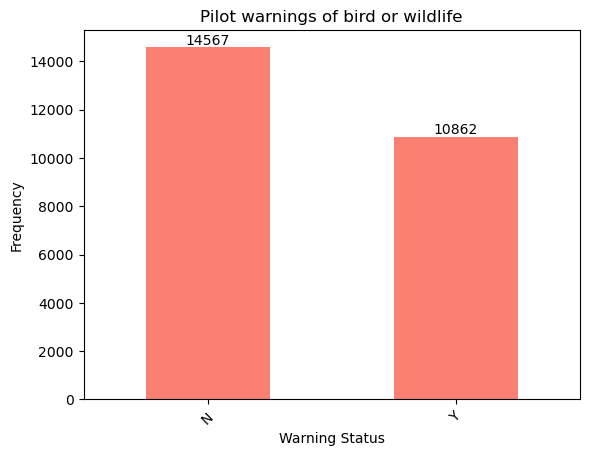

```python
ax=warnings_count.plot(kind='bar',color='salmon')
ax.bar_label(ax.containers[0])
plt.xlabel("Warning Status")
plt.ylabel("Frequency")
plt.xticks(rotation=45)
plt.title("Pilot warnings of bird or wildlife")
plt.show()
```

📌 10862 incidents where pilot was warned about the birds.

Relation between prior warning and effect of strike

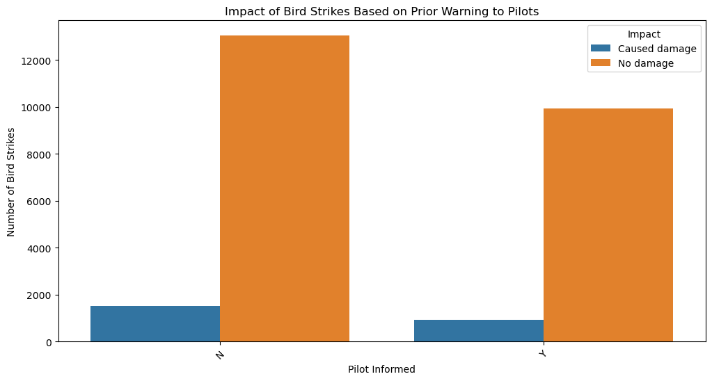

```python
plt.figure(figsize=(12, 6))
ax = sns.countplot(data=df, x='Pilot warned of birds or wildlife?', hue='Effect: Indicated Damage')
plt.title('Impact of Bird Strikes Based on Prior Warning to Pilots')
plt.xlabel('Pilot Informed')
plt.ylabel('Number of Bird Strikes')
plt.legend(title='Impact')
plt.xticks(rotation=45)


plt.show()
```